# Day 4

# Maps: GIS and Coordinate reference systems (CRS)

## What is GIS?

GIS stands for `Geographic Information System`s.

It is a computer system for capturing, storing, checking, and displaying data related to positions on Earth’s surface.

- This is a terrific resource: [National Geopgraphic - GIS](https://education.nationalgeographic.org/resource/geographic-information-system-gis/)
- This is another: [ESRI - What is GIS?](https://www.esri.com/en-us/what-is-gis/overview)

## What is a CRS?

CRS stands for `Coordinate Reference System`.

A coordinate reference system, or CRS, is how spatial data that represent the earth’s **round AND 3-Dimensional** surface are flattened onto a 2 dimensional surface (think of squishing half of a tennis ball flat so that it could be represented on a piece of paper).

There are Geographic Coordinate Systems which have angular units and are developed from a spheroid representation of the Earth, and a *prime meridian* for reference. There are also projected coordinate systems which have linear units (e.g. feet or meters).

Go through this tutorial to get a better understanding of coordinate reference systems: [Earth data science](https://www.earthdatascience.org/courses/earth-analytics/spatial-data-r/intro-to-coordinate-reference-systems/)

> The components of a CRS are:

## 1. Coordinate system

https://www.houseofmath.com/encyclopedia/functions/theory-of-functions/fundamentals-of-functions/what-is-a-coordinate-system

[figure not shown]

- [Source](https://dctqed2pc42y2.cloudfront.net/overleaf-assets/images/s140_koordinatsystem1eng.svg)

## 2. Units of the datum (horizontal and vertical)

If your spatial analysis requires distance in meters, you will need to make sure that your Coordinate Reference System is in meters. UTM stands for Universal Transverse Mercator and is one of the main CRS’s you will encounter. The UTM CRS contains a series of small projections that minimize the distortion you might see if you use latitude and longitude. A geographic coordinate, such as the one on the left below, has angular units.

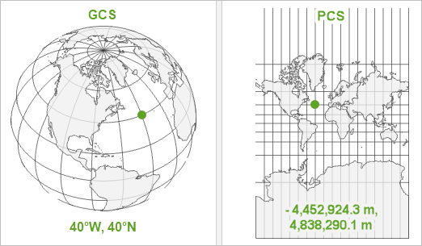

https://esri.com/arcgis-blog/products/arcgis-pro/mapping/coordinate-systems-difference/

- [*Source: ESRI*](https://developers.arcgis.com/python/guide/part1-introduction-what-is-geometry/)

## 3. The Datum

Geographic information system datum define the position of the spheroid relative to the center of the earth.

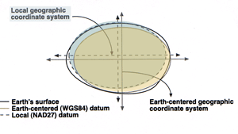

https://www.esri.com/news/arcuser/0401/datum.html

- [*Source: ESRI*](https://www.esri.com/news/arcuser/0401/graphics/geoids.gif)

## 4. Projection information

Again, the projection is a representation of a round surface (the Earth) onto a 2-dimensional flat surface (a map). This involves algorithms that transform each of the Earth’s graticules (lines on the earth, latitude and longitude) onto a flat surface. The projection information documents how this was done and what the units of the outcome are.

- This is a great source for CRS numeric codes: https://spatialreference.org/ref/epsg/
- And another resource: https://bookdown.org/mcwimberly/gdswr-book/coordinate-reference-systems.html

# Points, Lines, and Polygons

- **Points** are simply a pair of geographic coordinates, like a X-Y pair on a plot. They are dimensionless. Examples of point data in GIS are locations of trees in a park, locations where you stopped on a hike, or locations of defibrillators in a building.
- **Lines** are a series of connected points. Examples are depictions of roads, railways, and hiking trails.
- **Polygons** are a series of lines that connect with area in the middle. Think of lakes, a soccer field, or a county boundary. Sometimes polygons can have holes or spaces in them like a donut. An example is a lake with islands in the middle of it.

A collection of each of these GIS shapes can be stored in a single object. Examples include:

- A collection of points showing the location of every school or hospital
- A collection of lines showing the entire highway system
- A collection of polygons showing every county in the state

[figure not shown]

https://developers.arcgis.com/python/guide/part1-introduction-what-is-geometry/

## Rasters

Rasters are continuous data, think of color spectra or the range of moods you may have from very angry to quite happy. You are rarely just one of these and there are infinite gradations depending on how irksome other drivers are or if you got the perfect birthday cupcake.

Rasters come from technologies such as aerial photography and remote sensing imagery. The colors or variations in the cells reflect information like air pollution concentrations or tree canopy cover.

Rasters are stored in a matrix of cells, like a table and the size of the cell represents the resolution of the information. If the cell is 50m x 50m, then there will be no additional information variation within that size of a cell. If the raster was showing temperature, then their will be a single temperature value for that entire. The smaller the cell size, the greater or finer the resolution of the data.

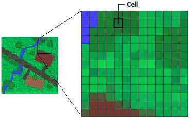

https://desktop.arcgis.com/en/arcmap/latest/manage-data/raster-and-images/what-is-raster-data.htm

# **sf** is so awesome

## Spatial analysis with R

A powerful tool in R for spatial analysis and geography data processing is the [sf package](https://r-spatial.github.io/sf/).

[figure not shown]

https://gist.github.com/edzer/f461a3a95570c4ab7edf3125c2f19d20

## Reading in data

The main type of data you will be reading in are [shapefiles](https://en.wikipedia.org/wiki/Shapefile). Shapefiles are not one file, but are actually a set of files that include the data, the attributes of the coordinates, the projection, the coordinates, and information that tells the software the type of data it is.

The other main type of data you will experience is a flat table of data with x,y coordinates, like longitude and latitude. This is the type of data we will work with today, but once we set it up as a spatial data set, we will save it as a shapefile.

Let’s pull in some point data. Each point in this data represents a specific tree in San Francisco.

> Read more about this dataset at [San Francisco Trees](https://github.com/rfordatascience/tidytuesday/tree/master/data/2020/2020-01-28)

```r
library(sf)
library(tidyverse)

sf_trees <- read_csv("https://raw.githubusercontent.com/rfordatascience/tidytuesday/master/data/2020/2020-01-28/sf_trees.csv")
```

Now, let’s look at the data.

```r
View(sf_trees)

class(sf_trees)
```

The dataframe has latitude and longitude columns containing each point’s coordinates, but R does not yet know that this is a geographic data set. If we begin with a CSV file of coordinates, we must tell R to convert it to a spatial dataset. This will add a new `geometry` column to the dataframe, which will be used for mapping the data.

```r
# Error!
sf_trees_geo <- st_as_sf(sf_trees,
                         coords = c("longitude", "latitude"),
                         crs = 4269,
                         remove = FALSE)
```

Drats! R is right again. There are some missing coordinates or NA’s in the latitude and longitude columns. If we attempt to convert the missing data to a `geometry` we will get an error for missing coordinates.

Let’s get rid of the trees/rows with missing coordinates.

```r
# With filter() and !is.na()
sf_trees <- filter(sf_trees,
                   !is.na(longitude),
                   !is.na(latitude))

# Alternative: drop_na( )
## If NA appears in *either* of the columns you provide, the row will be dropped
sf_trees <- drop_na(sf_trees,
                    longitude,
                    latitude)
```

Now that we have filtered out the missing latitude and longitude values, we will run the [st_as_sf() function](https://www.rdocumentation.org/packages/sf/versions/1.0-14/topics/st_as_sf). This function requires the data, the name of the columns that contain the coordinates, and the data’s coordinate reference system.

> If you include the argument, `remove = FALSE`, your latitude and longitude columns will be retained in addtion to adding a `geometry` column. Otherwise they will be removed as they are combined into the `geometry`.

```r
sf_trees_geo <- st_as_sf(sf_trees,
                         coords = c("longitude", "latitude"),
                         crs = 4269,
                         remove = FALSE)
```

To check this worked properly, try making a simple plot of the data using the base R function `plot()`. To start, we will only map the first column. This is simply to make the plotting faster. Feel free to try plotting all of the attributes and see what happens. *Heads up, this may take a few minutes for large datasets like this one.*

> It will be difficult to see what is going on here, since at least one tree is very far away from the rest of the trees. Apparently out in the middle of the ocean. Perhaps it is growing on a ship?

```r
# Show a single layer
#plot(sf_trees_geo[1])

# Show all the layers
#plot(sf_trees_geo)
```

> It looks like there is at least one tree that is quite far from the others. We are really only interested in the trees within the City of San Francisco border. So, let’s look at which trees are within or overlap with the City of San Francisco limits.

We first need to read in a city spatial dataset. Then we will filter it to only include San Francisco, and then finally run the intersection/within function.

### 1. City data

The **tigris** package allows us to pull political boundaries, like cities, into R.

```r
library(tigris)
options(tigris_use_cache = TRUE)

cities <- metro_divisions()
```

### 2. Filter to San Francisco

We’ll use `str_detect()`, which tests whether some given characters occur anywhere in a string of text.

> **NOTE:** `str_detect` performs the same task as `grepl` in the video, with the benefit of putting the name of the column as the first argument.

Filtering using [str_detect()](https://stringr.tidyverse.org/reference/str_detect.html) is useful when you aren’t sure if San Francisco will be proceeded by “the City of”, or some similar but slightly different text. There is an entire [cheatsheet](https://rstudio.github.io/cheatsheets/html/strings.html) for working with strings, so check it out when you need to search for a certain word or manipulate text in some way.

```r
san_fran <- filter(cities, str_detect(NAME, "San Francisco"))

#plot(san_fran[1])
```

### 3. View the coordinate reference system

To do an intersection or check where things overlap, the two datasets need to be using the same CRS. Let’s check.

```r
st_crs(san_fran)
```

```
## Coordinate Reference System:
##   User input: NAD83
##   wkt:
## GEOGCRS["NAD83",
##     DATUM["North American Datum 1983",
##         ELLIPSOID["GRS 1980",6378137,298.257222101,
##             LENGTHUNIT["metre",1]]],
##     PRIMEM["Greenwich",0,
##         ANGLEUNIT["degree",0.0174532925199433]],
##     CS[ellipsoidal,2],
##         AXIS["latitude",north,
##             ORDER[1],
##             ANGLEUNIT["degree",0.0174532925199433]],
##         AXIS["longitude",east,
##             ORDER[2],
##             ANGLEUNIT["degree",0.0174532925199433]],
##     ID["EPSG",4269]]
```

```r
st_crs(sf_trees_geo)
```

```
## Coordinate Reference System:
##   User input: EPSG:4269
##   wkt:
## GEOGCRS["NAD83",
##     DATUM["North American Datum 1983",
##         ELLIPSOID["GRS 1980",6378137,298.257222101,
##             LENGTHUNIT["metre",1]]],
##     PRIMEM["Greenwich",0,
##         ANGLEUNIT["degree",0.0174532925199433]],
##     CS[ellipsoidal,2],
##         AXIS["geodetic latitude (Lat)",north,
##             ORDER[1],
##             ANGLEUNIT["degree",0.0174532925199433]],
##         AXIS["geodetic longitude (Lon)",east,
##             ORDER[2],
##             ANGLEUNIT["degree",0.0174532925199433]],
##     USAGE[
##         SCOPE["Geodesy."],
##         AREA["North America - onshore and offshore: Canada - Alberta; British Columbia; Manitoba; New Brunswick; Newfoundland and Labrador; Northwest Territories; Nova Scotia; Nunavut; Ontario; Prince Edward Island; Quebec; Saskatchewan; Yukon. Puerto Rico. United States (USA) - Alabama; Alaska; …
##         BBOX[14.92,167.65,86.45,-40.73]],
##     ID["EPSG",4269]]
```

> Ooofda. That’s a lot of information. The important part is that their last line showing their EPSG ID as `4269` id identical. We are good to go.

### 4. Intersects / Overlaps / Is within

Order of arguments?

```r
trees_in_san_fran <- st_intersection(sf_trees_geo, san_fran)
```

Look at our new data in the environment: `trees_in_san_fran`. You will see that we filtered out some of the tree records because they didn’t intersect with the boundary of the City of San Francisco. The number of rows was reduced from 19,006 to 18,994.

Take a look at the new tree map.

```r
# Plots a single layer
#plot(trees_in_san_fran[1])
```

## st_write

Since we are very interested in these trees and know we’ll use the data later, let’s save this new spatial data set with `st_write()`.

The first argument in `st_write()` is the name of the data in R we are saving, and the second argument is the file location and name to save to. The **.shp** file ending saves the data as a spatial shapefile. This is a common GIS file format for ESRI users and consists of several files.

The main files have the following extensions:

- `.prj`: The detailed projection information, such as *Lat/Long* or *UTM*
- `.dbf`: The attribute data, or the columns of data in our dataframe
- `.shp`: The shape information, or the *geometry* column in our dataframe

> Another common spatial format is **.geojson**, which has the advantage of only being a single file. This makes it easier to share with others and will generally save a bit of storage space.

Finally, we include `delete_layer = TRUE` to the **st_write** funciton to say it’s okay to save over previous versions of the file if it already exist in the folder we are saving to.

```r
# Save as a shapefile (multiple files, good for ESRI/ArcGIS)
st_write(trees_in_san_fran,
         "trees_in_san_fran.shp",
         delete_layer = TRUE)

# Save as geojson (single file, good for sharing)
st_write(trees_in_san_fran,
         "trees_in_san_fran.geojson",
         delete_layer = TRUE)
```

# **sf** spatial analysis (Part 2)

## Buffers: Go beyond the point

Let’s draw a buffer around each tree in our filtered data set. In your work you may need to draw buffers around point data either when locations are uncertain to a specific level of precision, or for example, if you want to find how many people live within 5 miles of a school or hospital.

To draw a buffer we want to make sure the coordinates are linear rather than angular. Remember when we talked about coordinate reference systems? Lat/Long uses angular coordinates and is not so great for calculating distances between points or areas of polygons. The Universal Transverse Mercator or UTM system on the other hand has coordinates in meters and is great for calculating surface distances.

> San Francisco is in UTM zone 10: CRS = 32610.

```r
# Convert CRS from Lat/Long to UTM zone 10 (San Francisco)
trees_in_san_fran <- st_transform(trees_in_san_fran, crs = 32610)

# Add a 1,000 meter (1 KM) buffer around each tree
trees_in_san_fran <- st_buffer(trees_in_san_fran, dist = 1000)

# View the new plot, w/ BIG overlapping circles
#plot(trees_in_san_fran[1])
```

## Going the distance

As a next step, we will calculate the distances between the trees and another location of interest. Let’s find which tree is closest to a specific loon floating on Leech Lake all the way over in Minnesota. *(As one does.)*

Below, we create a dataset with a single point using the coordinates stored as latitude and longitude. This is our special loon!

1. Use [st_point()](https://rdrr.io/github/etiennebr/geotidy/man/st_point.html) to tell R these are spatial coordinates and not just numbers.
2. Use [st_sfc()](https://r-spatial.github.io/sf/reference/sfc.html) to create a simple feature geometry list.
3. Use [st_as_sf()](https://www.rdocumentation.org/packages/sf/versions/1.0-14/topics/st_as_sf) to make the point a simple feature object with an assigned coordinate reference system (CRS).

### 1. Create the loon coordinates

```r
# Our very exact loon coordinates in MN
loon_lat <- 47.1505

loon_long <- -94.3839

# Add coords to a dataframe
loon_coords <- data.frame(lake = "Leech Lake",
                          lon = loon_long,
                          lat = loon_lat)
```

### 2. Convert dataframe to a sf spatial object

> The CRS ID for Lat/Long data is `4269`.

```r
loon_mn <- st_as_sf(loon_coords,
                    coords = c("lon", "lat"),
                    crs = 4269)
```

### 3. Transform both to the same CRS

```r
loon_mn <- st_transform(loon_mn, crs = 4326)
```

```r
trees_in_san_fran <- st_transform(trees_in_san_fran, crs = 4326)
```

## Calculate the **st_distance( )**

We’ll use the `st_distance()` function to calculate the distance between each of the trees and our loon. We can also add an `*_km` column by dividing the distance by 1,000 meters. The `as.numeric()` is added to remove the *meters* units from the original distance value.

```r
trees_in_san_fran <- trees_in_san_fran %>%
  mutate(distance_to_loon_m = st_distance(geometry, loon_mn),
         distance_to_loon_km = as.numeric(distance_to_loon_m) / 1000)
```

To determine the closest tree in San Francisco to our loon we use the *min()* function, which will return the minimum calculated value in the column. Let’s run *min()* on the column `distance_to_leech_km`, and use `filter()` to keep the one row where its distance is equal to the minimum distance.

```r
trees_in_san_fran %>%
  filter(distance_to_loon_km == min(distance_to_loon_km)) %>% glimpse()
```

```
## Rows: 1
## Columns: 27
## $ tree_id             <dbl> 256051
## $ legal_status        <chr> "Undocumented"
## $ species             <chr> "Platanus x hispanica :: Sycamore: London Plane"
## $ address             <chr> "200 The Embarcadero"
## $ site_order          <dbl> 8
## $ site_info           <chr> "Sidewalk: Curb side : Cutout"
## $ caretaker           <chr> "DPW"
## $ date                <date> NA
## $ dbh                 <dbl> NA
## $ plot_size           <chr> "3x3"
## $ latitude            <dbl> 37.79167
## $ longitude           <dbl> -122.3904
## $ CSAFP               <chr> "488"
## $ CBSAFP              <chr> "41860"
## $ METDIVFP            <chr> "41884"
## $ GEOID               <chr> "4186041884"
## $ NAME                <chr> "San Francisco-San Mateo-Redwood City, CA"
## $ NAMELSAD            <chr> "San Francisco-San Mateo-Redwood City, CA Metro Di…
## $ LSAD                <chr> "M3"
## $ MTFCC               <chr> "G3120"
## $ ALAND               <dbl> 1283429131
## $ AWATER              <dbl> 1236270696
## $ INTPTLAT            <chr> "+37.5126658"
## $ INTPTLON            <chr> "-122.4361768"
## $ geometry            <POLYGON [°]> POLYGON ((-122.3791 37.7916...
## $ distance_to_loon_m  [m] <units[1 x 1]>
## $ distance_to_loon_km <dbl> 2502.987
```

That’s our tree! Number `256051`. The bark shedding *Platanus x hispanica*, aka, the London plane tree.

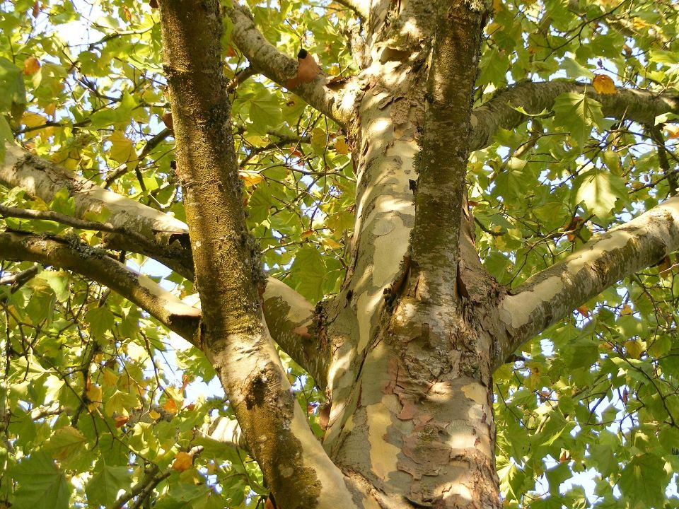